# Heart Attack Risk Analysis

[figure not shown]

## Overview

The aim of this competition is to train a model to predict whether or not a patient is at **high risk** or **low risk** of a heart attack.

## Description

This dataset provides a comprehensive array of features relevant to heart health and lifestyle choices, encompassing patient-specific details such as age, gender, cholesterol levels, blood pressure, heart rate, and indicators like diabetes, family history, smoking habits, obesity, and alcohol consumption. Additionally, lifestyle factors like exercise hours, dietary habits, stress levels, and sedentary hours are included. Medical aspects comprising previous heart problems, medication usage, and triglyceride levels are considered. Socioeconomic aspects such as income and geographical attributes like country, continent, and hemisphere are incorporated.

### Files

- train.csv - the training set
- test.csv - the test set
- sample_submission.csv - a sample submission file in the correct format

### Columns

- `Patient ID` - Unique identifier for each patient
- `Age` - Age of the patient
- `Sex` - Gender of the patient (Male/Female)
- `Cholesterol` - Cholesterol levels of the patient
- `Blood Pressure` - Blood pressure of the patient (systolic/diastolic)
- `Heart Rate` - Heart rate of the patient
- `Diabetes` - Whether the patient has diabetes (Yes/No)
- `Family History` - Family history of heart-related problems (1: Yes, 0: No)
- `Smoking` - Smoking status of the patient (1: Smoker, 0: Non-smoker)
- `Obesity` - Obesity status of the patient (1: Obese, 0: Not obese)
- `Alcohol` Consumption - Level of alcohol consumption by the patient (None/Light/Moderate/Heavy)
- `Exercise Hours Per Week` - Number of exercise hours per week
- `Diet` - Dietary habits of the patient (Healthy/Average/Unhealthy)
- `Previous Heart Problems` - Previous heart problems of the patient (1: Yes, 0: No)
- `Medication Use` - Medication usage by the patient (1: Yes, 0: No)
- `Stress Level` - Stress level reported by the patient (1-10)
- `Sedentary Hours Per Day` - Hours of sedentary activity per day
- `Income` - Income level of the patient
- `BMI` - Body Mass Index (BMI) of the patient
- `Triglycerides` - Triglyceride levels of the patient
- `Physical Activity Days Per Week` - Days of physical activity per week
- `Sleep Hours Per Day` - Hours of sleep per day
- `Country` - Country of the patient
- `Continent` - Continent where the patient resides
- `Hemisphere` - Hemisphere where the patient resides
- `Heart Attack Risk` - Presence of heart attack risk (1: Yes, 0: No)

# Workflow

## 1. Download the Dataset

- Download data from Kaggle
- View dataset files
- Load training set with Pandas
- Load test set with Pandas

### Download data from Kaggle

```python
import opendatasets as od
```

```python
dataset_url = 'https://www.kaggle.com/competitions/heart-attack-risk-analysis/overview'
```

```python
od.download(dataset_url)
```

```
Skipping, found downloaded files in "./heart-attack-risk-analysis" (use force=True to force download)
```

```python
data_dir = './heart-attack-risk-analysis'
```

### View dataset files

```python
# List of files with size
!ls -lh {data_dir}
```

```
σύνολο 1,5M
-rw-rw-r-- 1 themis themis  19K Φεβ  17 12:02 sample_submission.csv
-rw-rw-r-- 1 themis themis 281K Φεβ  17 12:02 test.csv
-rw-rw-r-- 1 themis themis 1,2M Φεβ  17 12:02 train.csv
```

```python
# No. of lines in test set
!wc -l {data_dir}/train.csv
```

```
7011 ./heart-attack-risk-analysis/train.csv
```

### Loading Training Set

```python
import pandas as pd
import random
```

```python
df=pd.read_csv(data_dir+"/train.csv")
df.head()
```

|  | Patient ID | Age | Sex | Cholesterol | Blood Pressure | Heart Rate | Diabetes | Family History | Smoking | Obesity | ... | Sedentary Hours Per Day | Income | BMI | Triglycerides | Physical Activity Days Per Week | Sleep Hours Per Day | Country | Continent | Hemisphere | Heart Attack Risk |
| --- | --- | --- | --- | --- | --- | --- | --- | --- | --- | --- | --- | --- | --- | --- | --- | --- | --- | --- | --- | --- | --- |
| 0 | RDG0550 | 33 | Male | 200 | 129/90 | 48 | 0 | 1 | 1 | 1 | ... | 0.138443 | 184066 | 30.449815 | 63 | 6 | 7 | Argentina | South America | Southern Hemisphere | 1 |
| 1 | NMA3851 | 56 | Female | 262 | 159/105 | 46 | 1 | 0 | 1 | 0 | ... | 0.369552 | 211755 | 34.973685 | 333 | 7 | 8 | Nigeria | Africa | Northern Hemisphere | 1 |
| 2 | TUI5807 | 19 | Female | 140 | 161/109 | 54 | 0 | 1 | 0 | 0 | ... | 8.646334 | 252203 | 30.554246 | 537 | 2 | 10 | Thailand | Asia | Northern Hemisphere | 0 |
| 3 | YYT5016 | 50 | Female | 163 | 120/62 | 53 | 0 | 1 | 1 | 1 | ... | 1.107884 | 121954 | 35.390265 | 591 | 0 | 9 | Spain | Europe | Southern Hemisphere | 1 |
| 4 | ZAC5937 | 89 | Female | 144 | 153/110 | 92 | 1 | 0 | 1 | 0 | ... | 1.337570 | 180121 | 39.575483 | 145 | 2 | 5 | Germany | Europe | Northern Hemisphere | 1 |

5 rows × 26 columns

```python
df.info()
```

```
<class 'pandas.core.frame.DataFrame'>
RangeIndex: 7010 entries, 0 to 7009
Data columns (total 26 columns):
 #   Column                           Non-Null Count  Dtype
---  ------                           --------------  -----
 0   Patient ID                       7010 non-null   object
 1   Age                              7010 non-null   int64
 2   Sex                              7010 non-null   object
 3   Cholesterol                      7010 non-null   int64
 4   Blood Pressure                   7010 non-null   object
 5   Heart Rate                       7010 non-null   int64
 6   Diabetes                         7010 non-null   int64
 7   Family History                   7010 non-null   int64
 8   Smoking                          7010 non-null   int64
 9   Obesity                          7010 non-null   int64
```

[output cut: 18 more lines]

No missing values and all the data types are correct

```python
df.describe()
```

|  | Age | Cholesterol | Heart Rate | Diabetes | Family History | Smoking | Obesity | Alcohol Consumption | Exercise Hours Per Week | Previous Heart Problems | Medication Use | Stress Level | Sedentary Hours Per Day | Income | BMI | Triglycerides | Physical Activity Days Per Week | Sleep Hours Per Day | Heart Attack Risk |
| --- | --- | --- | --- | --- | --- | --- | --- | --- | --- | --- | --- | --- | --- | --- | --- | --- | --- | --- | --- |
| count | 7010.000000 | 7010.000000 | 7010.000000 | 7010.000000 | 7010.000000 | 7010.000000 | 7010.000000 | 7010.000000 | 7010.000000 | 7010.000000 | 7010.000000 | 7010.000000 | 7010.000000 | 7010.00000 | 7010.000000 | 7010.000000 | 7010.000000 | 7010.000000 | 7010.000000 |
| mean | 53.510414 | 259.880742 | 75.105991 | 0.652782 | 0.491869 | 0.896291 | 0.499857 | 0.595863 | 9.979109 | 0.498146 | 0.500143 | 5.451783 | 5.994007 | 158245.34893 | 28.878692 | 416.782026 | 3.491583 | 7.024822 | 0.357204 |
| std | 21.290957 | 80.709248 | 20.507160 | 0.476120 | 0.499970 | 0.304904 | 0.500036 | 0.490759 | 5.769721 | 0.500032 | 0.500036 | 2.857989 | 3.472022 | 80585.31666 | 6.322401 | 224.195136 | 2.281077 | 1.990908 | 0.479210 |
| min | 18.000000 | 120.000000 | 40.000000 | 0.000000 | 0.000000 | 0.000000 | 0.000000 | 0.000000 | 0.002442 | 0.000000 | 0.000000 | 1.000000 | 0.001263 | 20062.00000 | 18.002337 | 30.000000 | 0.000000 | 4.000000 | 0.000000 |
| 25% | 35.000000 | 192.000000 | 57.000000 | 0.000000 | 0.000000 | 1.000000 | 0.000000 | 0.000000 | 5.046024 | 0.000000 | 0.000000 | 3.000000 | 2.971831 | 88368.00000 | 23.422280 | 221.000000 | 2.000000 | 5.000000 | 0.000000 |
| 50% | 53.000000 | 259.000000 | 75.000000 | 1.000000 | 0.000000 | 1.000000 | 0.000000 | 1.000000 | 9.982968 | 0.000000 | 1.000000 | 5.000000 | 5.936919 | 157378.50000 | 28.737627 | 416.000000 | 3.000000 | 7.000000 | 0.000000 |
| 75% | 72.000000 | 329.000000 | 93.000000 | 1.000000 | 1.000000 | 1.000000 | 1.000000 | 1.000000 | 15.029659 | 1.000000 | 1.000000 | 8.000000 | 9.017592 | 227218.50000 | 34.321158 | 613.000000 | 5.000000 | 9.000000 | 1.000000 |
| max | 90.000000 | 400.000000 | 110.000000 | 1.000000 | 1.000000 | 1.000000 | 1.000000 | 1.000000 | 19.998709 | 1.000000 | 1.000000 | 10.000000 | 11.999313 | 299954.00000 | 39.993581 | 800.000000 | 7.000000 | 10.000000 | 1.000000 |

No outliers!

### Load Test Set

```python
test_df=pd.read_csv(data_dir+"/test.csv")
```

```python
test_df.info()
```

```
<class 'pandas.core.frame.DataFrame'>
RangeIndex: 1753 entries, 0 to 1752
Data columns (total 25 columns):
 #   Column                           Non-Null Count  Dtype
---  ------                           --------------  -----
 0   Patient ID                       1753 non-null   object
 1   Age                              1753 non-null   int64
 2   Sex                              1753 non-null   object
 3   Cholesterol                      1753 non-null   int64
 4   Blood Pressure                   1753 non-null   object
 5   Heart Rate                       1753 non-null   int64
 6   Diabetes                         1753 non-null   int64
 7   Family History                   1753 non-null   int64
 8   Smoking                          1753 non-null   int64
 9   Obesity                          1753 non-null   int64
```

[output cut: 17 more lines]

No missing values and all the data types are correct

```python
test_df.describe()
```

|  | Age | Cholesterol | Heart Rate | Diabetes | Family History | Smoking | Obesity | Alcohol Consumption | Exercise Hours Per Week | Previous Heart Problems | Medication Use | Stress Level | Sedentary Hours Per Day | Income | BMI | Triglycerides | Physical Activity Days Per Week | Sleep Hours Per Day |
| --- | --- | --- | --- | --- | --- | --- | --- | --- | --- | --- | --- | --- | --- | --- | --- | --- | --- | --- |
| count | 1753.000000 | 1753.000000 | 1753.000000 | 1753.000000 | 1753.000000 | 1753.000000 | 1753.000000 | 1753.000000 | 1753.000000 | 1753.000000 | 1753.000000 | 1753.000000 | 1753.000000 | 1753.000000 | 1753.000000 | 1753.000000 | 1753.000000 | 1753.000000 |
| mean | 54.498003 | 259.863092 | 74.684541 | 0.650314 | 0.497433 | 0.899030 | 0.507701 | 0.606959 | 10.154940 | 0.486594 | 0.491158 | 5.541358 | 5.992424 | 158334.493440 | 28.942447 | 421.256132 | 3.482031 | 7.018254 |
| std | 21.070471 | 81.499465 | 20.727584 | 0.477007 | 0.500136 | 0.301375 | 0.500083 | 0.488565 | 5.839031 | 0.499963 | 0.500064 | 2.865841 | 3.444605 | 80557.632883 | 6.307835 | 221.979158 | 2.289753 | 1.979261 |
| min | 18.000000 | 120.000000 | 40.000000 | 0.000000 | 0.000000 | 0.000000 | 0.000000 | 0.000000 | 0.008115 | 0.000000 | 0.000000 | 1.000000 | 0.003625 | 20443.000000 | 18.004211 | 30.000000 | 0.000000 | 4.000000 |
| 25% | 36.000000 | 192.000000 | 56.000000 | 0.000000 | 0.000000 | 1.000000 | 0.000000 | 0.000000 | 4.819370 | 0.000000 | 0.000000 | 3.000000 | 3.100410 | 88117.000000 | 23.424618 | 239.000000 | 1.000000 | 5.000000 |
| 50% | 54.000000 | 258.000000 | 75.000000 | 1.000000 | 0.000000 | 1.000000 | 1.000000 | 1.000000 | 10.497572 | 0.000000 | 0.000000 | 6.000000 | 5.916726 | 160257.000000 | 28.892801 | 423.000000 | 3.000000 | 7.000000 |
| 75% | 73.000000 | 332.000000 | 92.000000 | 1.000000 | 1.000000 | 1.000000 | 1.000000 | 1.000000 | 15.212983 | 1.000000 | 1.000000 | 8.000000 | 9.021387 | 229490.000000 | 34.365926 | 610.000000 | 5.000000 | 9.000000 |
| max | 90.000000 | 400.000000 | 110.000000 | 1.000000 | 1.000000 | 1.000000 | 1.000000 | 1.000000 | 19.985813 | 1.000000 | 1.000000 | 10.000000 | 11.980970 | 299891.000000 | 39.997211 | 800.000000 | 7.000000 | 10.000000 |

No outliers!

## 2. Exploratory data analysis (EDA)

```python
import matplotlib
import matplotlib.pyplot as plt
import seaborn as sns
import plotly.express as px
sns.set_style('whitegrid')
matplotlib.rcParams['font.size'] = 14
matplotlib.rcParams['figure.figsize'] = (10, 6)
```

```python
df_eda=df.copy()
df_eda['Heart Attack Risk'] = df_eda['Heart Attack Risk'].apply(lambda x: 'Low' if x == 0 else 'High')
```

### Age

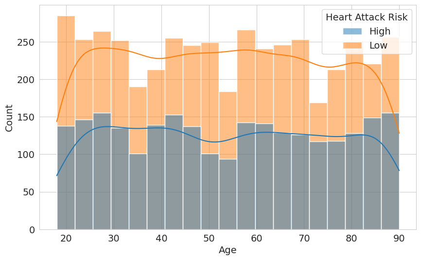

```python
sns.histplot(data=df_eda,x='Age',hue='Heart Attack Risk', kde=True)
plt.show()
```

### Sex

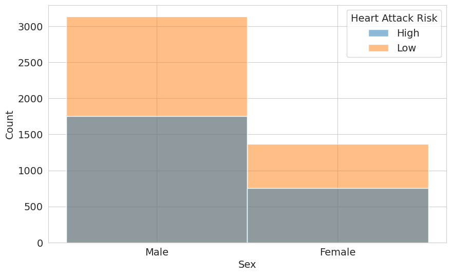

```python
sns.histplot(data=df_eda,x='Sex',hue='Heart Attack Risk',binwidth=1)
plt.show()
```

### Cholesterol

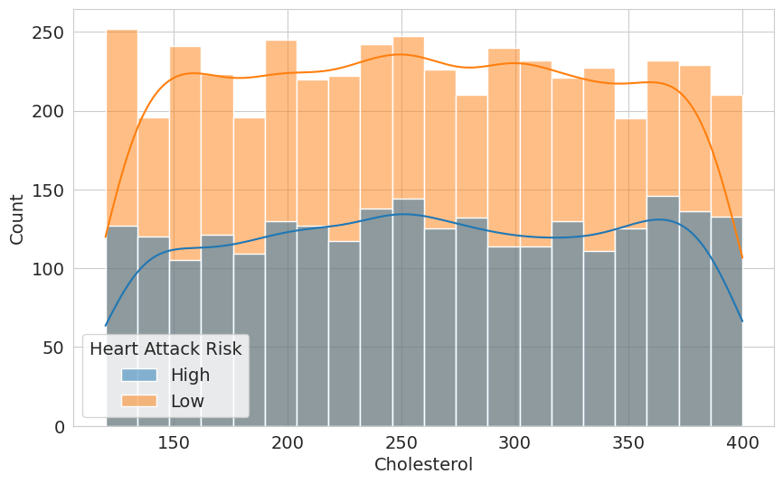

```python
sns.histplot(data=df_eda,x='Cholesterol',hue='Heart Attack Risk', kde=True)
plt.show()
```

### Blood Pressure

```python
df[['sys', 'dia']] = df['Blood Pressure'].str.split('/', expand=True).astype('int64')
df_eda[['sys', 'dia']] = df_eda['Blood Pressure'].str.split('/', expand=True).astype('int64')
test_df[['sys', 'dia']] = test_df['Blood Pressure'].str.split('/', expand=True).astype('int64')
```

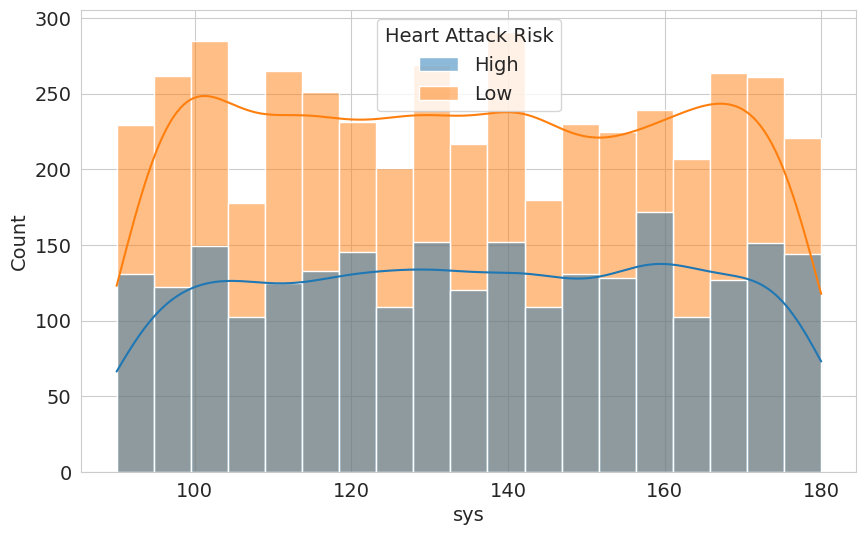

```python
sns.histplot(data=df_eda,x='sys', kde=True,hue='Heart Attack Risk')
plt.show()
```

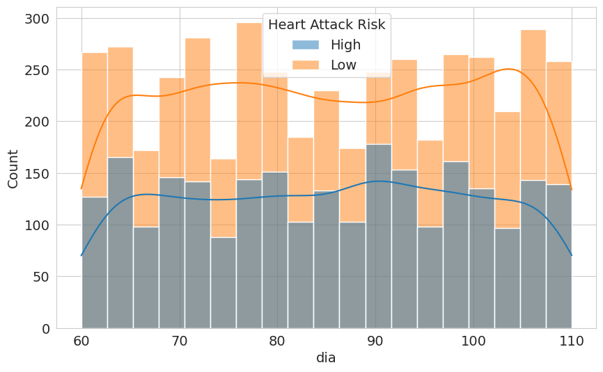

```python
sns.histplot(data=df_eda,x='dia', kde=True,hue='Heart Attack Risk')
plt.show()
```

### Heart Rate

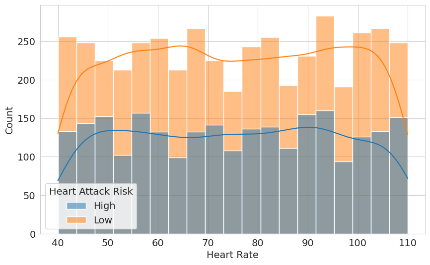

```python
sns.histplot(data=df_eda,x='Heart Rate',hue='Heart Attack Risk', kde=True)
plt.show()
```

### Diabetes

```python
df_eda['Diabetes'] = df_eda['Diabetes'].apply(lambda x: 'Yes' if x == 1 else 'No')
```

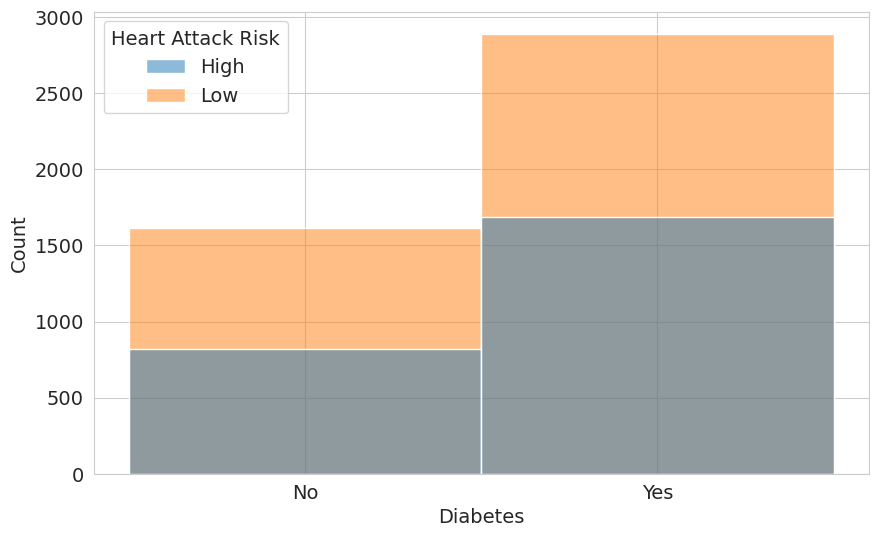

```python
sns.histplot(df_eda,x='Diabetes',hue='Heart Attack Risk')
plt.show()
```

### Family History

```python
df_eda['Family History'] = df_eda['Family History'].apply(lambda x: 'Yes' if x == 1 else 'No')
```

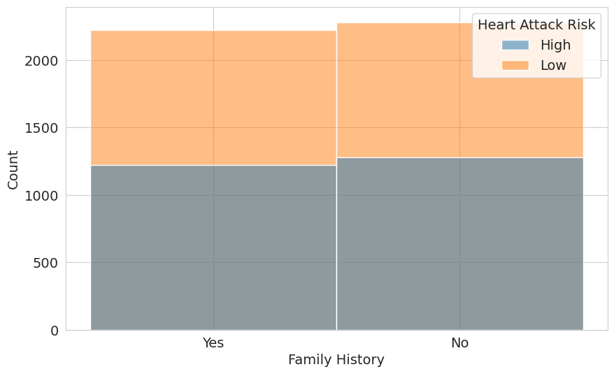

```python
sns.histplot(df_eda,x='Family History',hue='Heart Attack Risk',binwidth=1)
plt.show()
```

### Smoking

```python
df_eda['Smoking'] = df_eda['Smoking'].apply(lambda x: 'Smoker' if x == 1 else 'Non-Smoker')
```

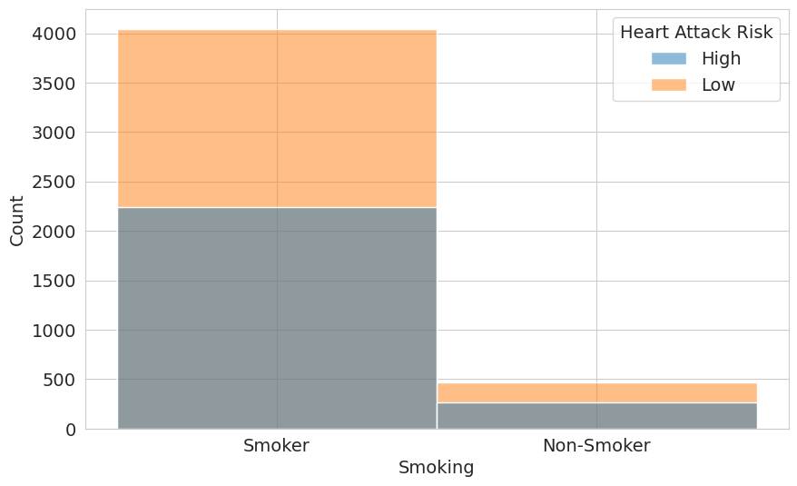

```python
sns.histplot(df_eda,x='Smoking',hue='Heart Attack Risk',binwidth=1)
plt.show()
```

### Obesity

```python
df_eda['Obesity'] = df_eda['Obesity'].apply(lambda x: 'Obese' if x == 1 else 'Not Obese')
```

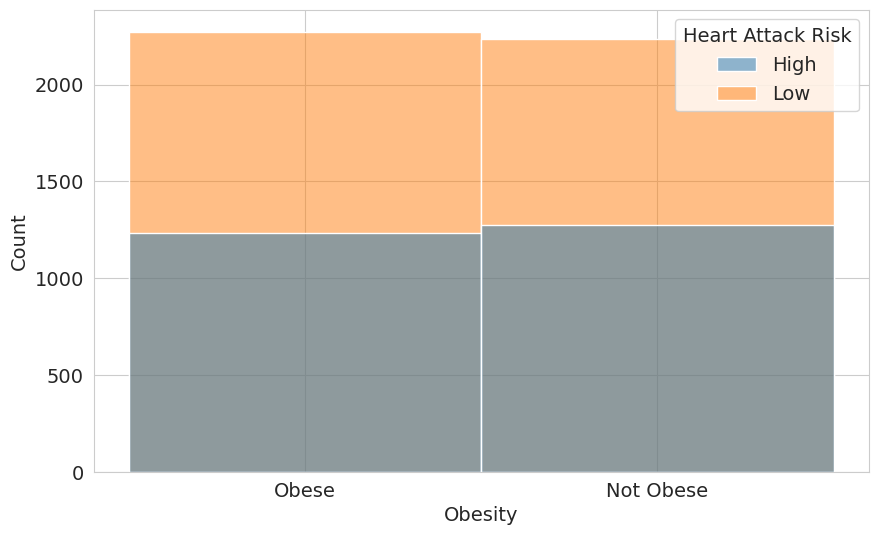

```python
sns.histplot(df_eda,x='Obesity',hue='Heart Attack Risk',binwidth=1)
plt.show()
```

### Alcohol Consumption

```python
df_eda['Alcohol Consumption'] = df_eda['Alcohol Consumption'].apply(lambda x: 'None' if x == 0 else 'Light')
```

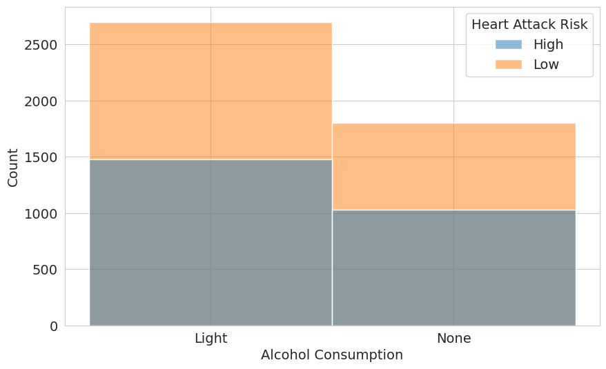

```python
sns.histplot(df_eda,x='Alcohol Consumption',hue='Heart Attack Risk',binwidth=1)
plt.show()
```

### Exercise Hours Per Week

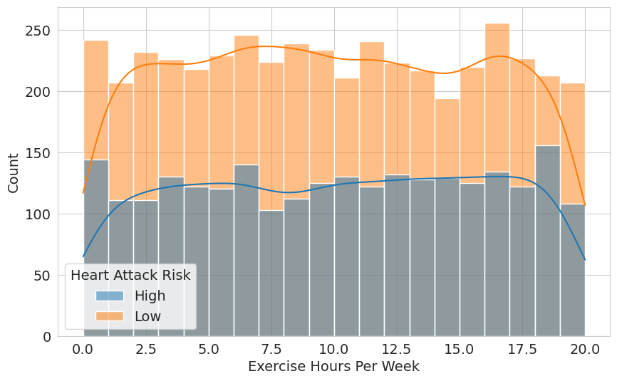

```python
sns.histplot(df_eda,x='Exercise Hours Per Week',hue='Heart Attack Risk',kde=True)
plt.show()
```

### Diet

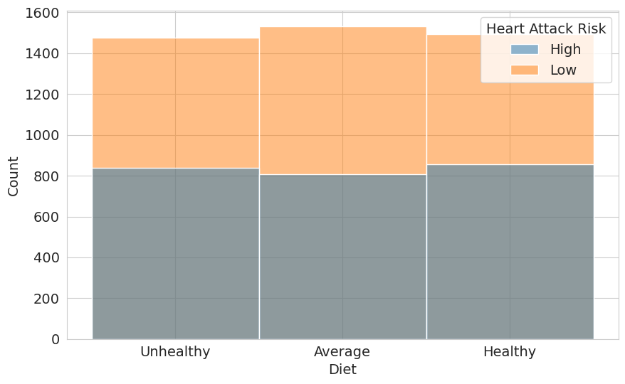

```python
sns.histplot(df_eda,x='Diet',hue='Heart Attack Risk',binwidth=1)
plt.show()
```

### Previous Heart Problems

```python
df_eda['Previous Heart Problems'] = df_eda['Previous Heart Problems'].apply(lambda x: 'Yes' if x == 1 else 'no')
```

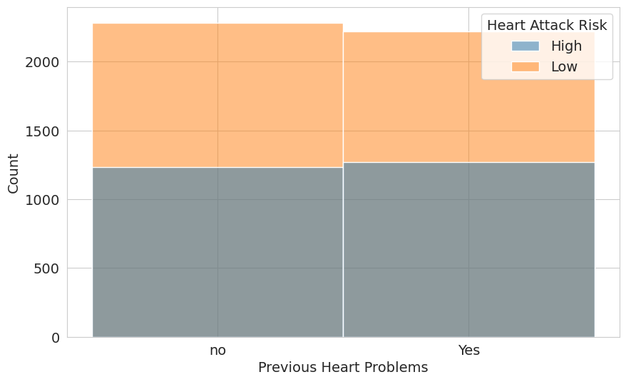

```python
sns.histplot(df_eda,x='Previous Heart Problems',hue='Heart Attack Risk',binwidth=1)
plt.show()
```

### Medication Use

```python
df_eda['Medication Use'] = df_eda['Medication Use'].apply(lambda x: 'Yes' if x == 1 else 'no')
```

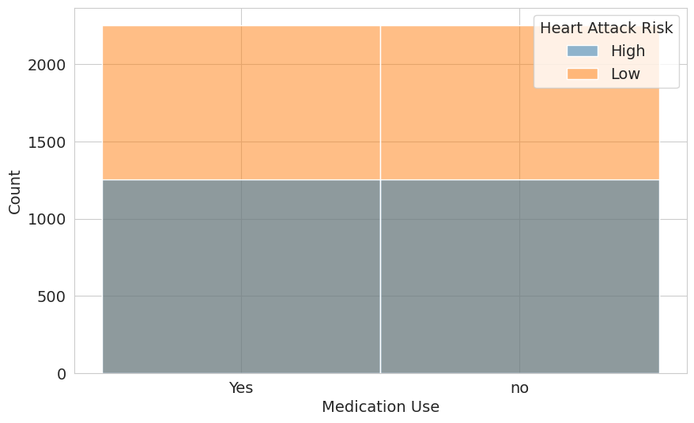

```python
sns.histplot(df_eda,x='Medication Use',hue='Heart Attack Risk',binwidth=1)
plt.show()
```

### Stress Level

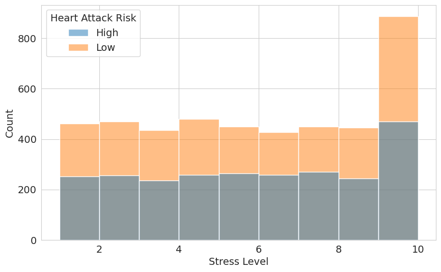

```python
sns.histplot(df_eda,x='Stress Level',hue='Heart Attack Risk',binwidth=1)
plt.show()
```

### Sedentary Hours Per Day

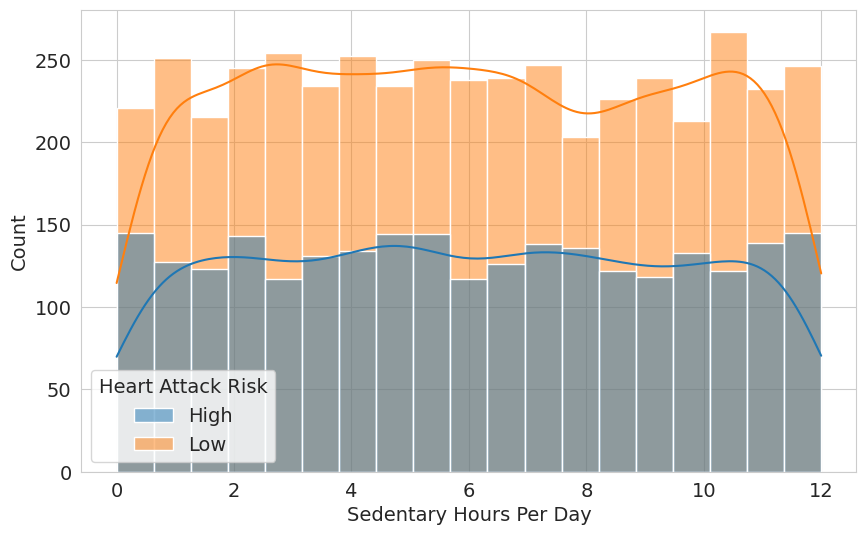

```python
sns.histplot(df_eda,x='Sedentary Hours Per Day',hue='Heart Attack Risk',kde=True)
plt.show()
```

### Income

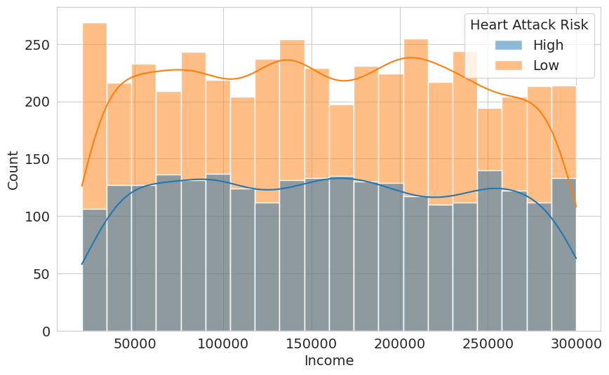

```python
sns.histplot(df_eda,x='Income',hue='Heart Attack Risk',kde=True)
plt.show()
```

### BMI

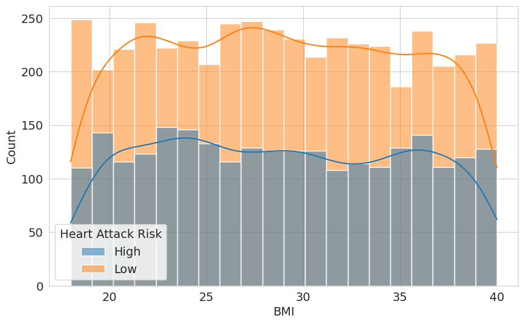

```python
sns.histplot(df_eda,x='BMI',hue='Heart Attack Risk',kde=True)
plt.show()
```

### Triglycerides

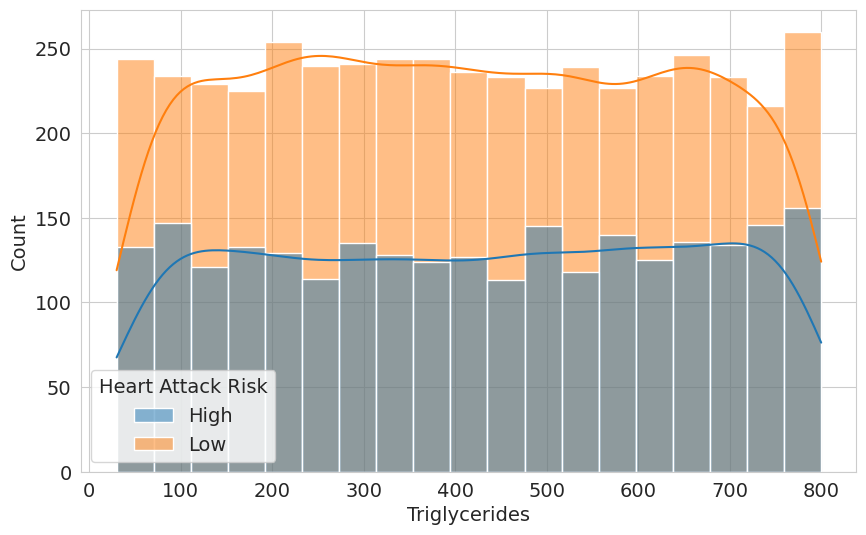

```python
sns.histplot(df_eda,x='Triglycerides',hue='Heart Attack Risk',kde=True)
plt.show()
```

### Physical Activity Days Per Week

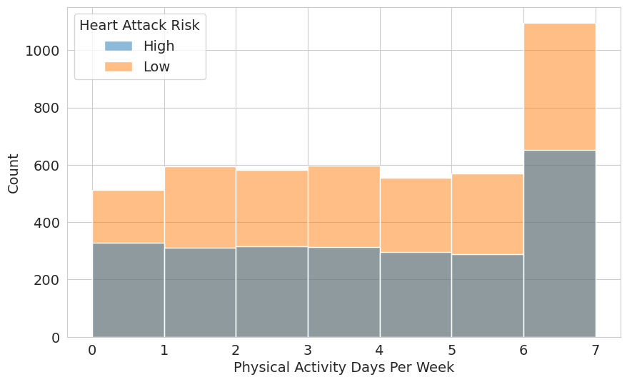

```python
sns.histplot(df_eda,x='Physical Activity Days Per Week',hue='Heart Attack Risk',binwidth=1)
plt.show()
```

### Sleep Hours Per Day

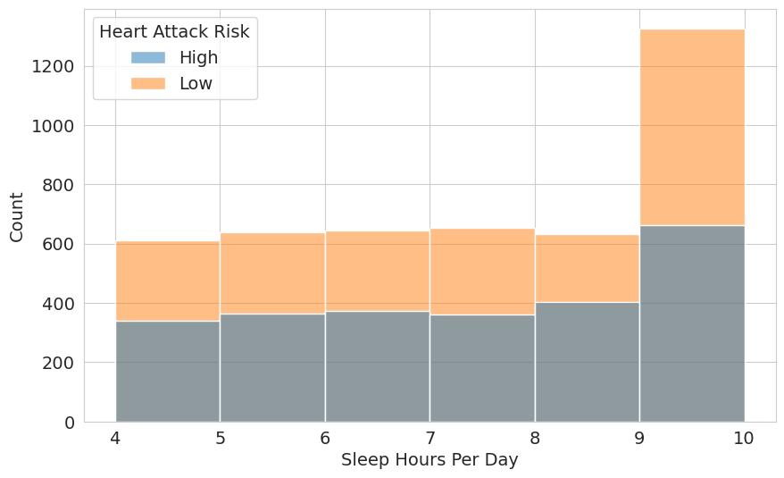

```python
sns.histplot(df_eda,x='Sleep Hours Per Day',hue='Heart Attack Risk',binwidth=1)
plt.show()
```

### Country

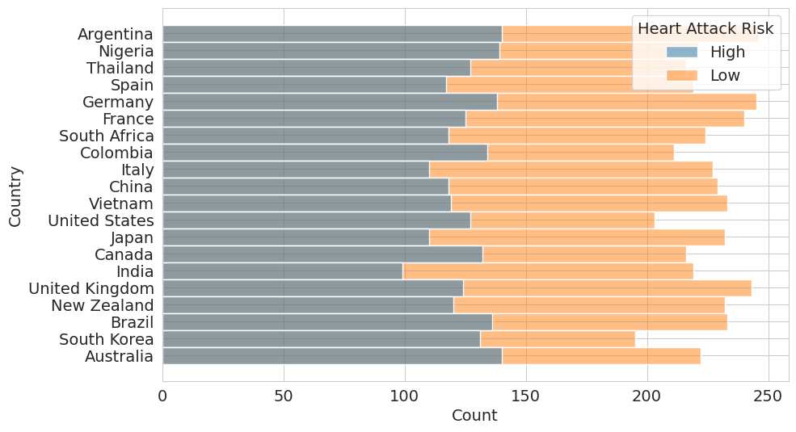

```python
sns.histplot(df_eda,y='Country',hue='Heart Attack Risk',binwidth=1)
plt.show()
```

### Continent

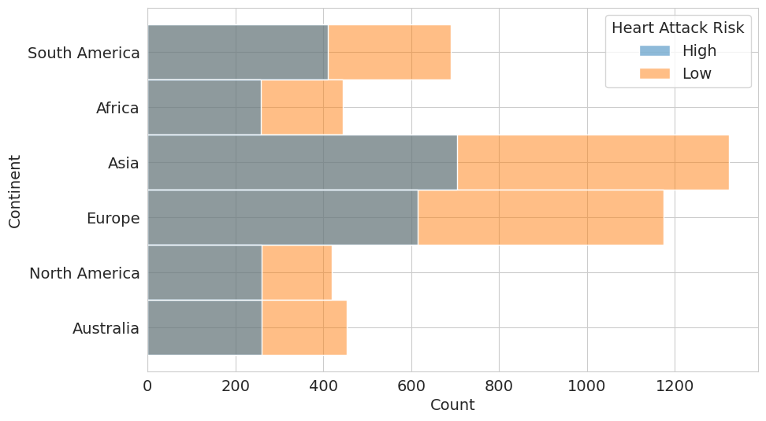

```python
sns.histplot(df_eda,y='Continent',hue='Heart Attack Risk',binwidth=1)
plt.show()
```

### Hemisphere

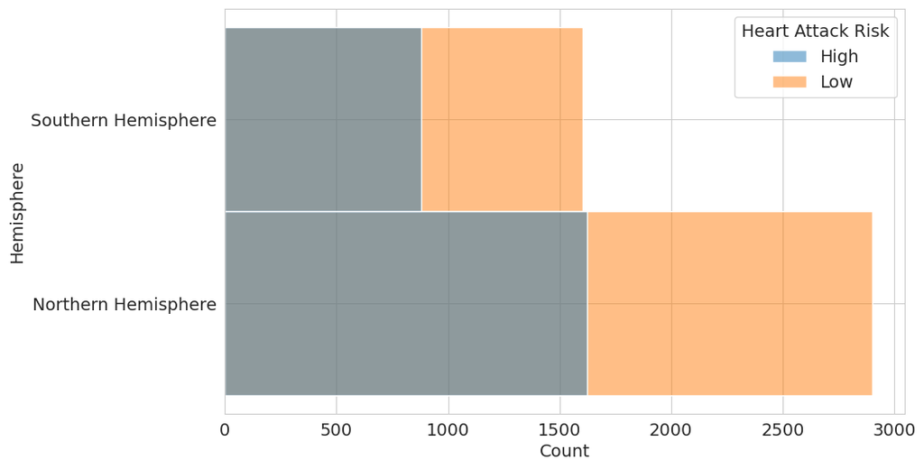

```python
sns.histplot(df_eda,y='Hemisphere',hue='Heart Attack Risk',binwidth=1)
plt.show()
```

## 3. Prepare Dataset for Training

- Split Training & Validation Set
- Extract Inputs & Outputs
  - Training
  - Validation
  - Test

### Split Training & Validation Set

We'll set aside 20% of the training data as the validation set, to evaluate the models we train on previously unseen data.

```python
from sklearn.model_selection import train_test_split
```

```python
train_df, val_df = train_test_split(df, test_size=0.2, random_state=358)
```

```python
len(train_df), len(val_df)
```

```
(5608, 1402)
```

### Extract Inputs and Outputs

```python
df.columns
```

```
Index(['Patient ID', 'Age', 'Sex', 'Cholesterol', 'Blood Pressure',
       'Heart Rate', 'Diabetes', 'Family History', 'Smoking', 'Obesity',
       'Alcohol Consumption', 'Exercise Hours Per Week', 'Diet',
       'Previous Heart Problems', 'Medication Use', 'Stress Level',
       'Sedentary Hours Per Day', 'Income', 'BMI', 'Triglycerides',
       'Physical Activity Days Per Week', 'Sleep Hours Per Day', 'Country',
       'Continent', 'Hemisphere', 'Heart Attack Risk', 'sys', 'dia'],
      dtype='object')
```

```python
input_cols=['Age', 'Sex', 'Cholesterol', 'sys', 'dia',
       'Heart Rate', 'Diabetes', 'Family History', 'Smoking', 'Obesity',
       'Alcohol Consumption', 'Exercise Hours Per Week', 'Diet',
       'Previous Heart Problems', 'Medication Use', 'Stress Level',
       'Sedentary Hours Per Day', 'Income', 'BMI', 'Triglycerides',
       'Physical Activity Days Per Week', 'Sleep Hours Per Day', 'Country',
       'Continent', 'Hemisphere']
```

```python
target_col='Heart Attack Risk'
```

#### Training

```python
train_inputs = train_df[input_cols].copy()
```

```python
train_targets = train_df[target_col].copy()
```

#### Validation

```python
val_inputs = val_df[input_cols].copy()
```

```python
val_targets = val_df[target_col].copy()
```

#### Test

```python
test_inputs = test_df[input_cols].copy()
```

```python
test_targets=[0 for i in range(len(test_df))]
```

### Identify numeric and categorical columns

Let's also identify which of the columns are numerical and which ones are categorical. This will be useful later, as we'll need to convert the categorical data to numbers for training a logistic regression model.

```python
num_cols = ['Age', 'Cholesterol', 'sys', 'dia',
       'Heart Rate', 'Exercise Hours Per Week', 'Stress Level',
       'Sedentary Hours Per Day', 'Income', 'BMI', 'Triglycerides']
```

### Scaling Numeric Features

Another good practice is to scale numeric features to a small range of values e.g. $(0,1)$ or $(-1,1)$. Scaling numeric features ensures that no particular feature has a disproportionate impact on the model's loss. Optimization algorithms also work better in practice with smaller numbers.

The numeric columns in our dataset have varying ranges.

```python
from sklearn.preprocessing import MinMaxScaler
```

```python
scaler = MinMaxScaler()
```

```python
scaler.fit(df[num_cols])
```

```
MinMaxScaler()
```

```python
train_inputs[num_cols] = pd.DataFrame(scaler.transform(train_inputs[num_cols]),
            columns=train_inputs[num_cols].columns,
            index=train_inputs[num_cols].index)
val_inputs[num_cols] = pd.DataFrame(scaler.transform(val_inputs[num_cols]),
            columns=val_inputs[num_cols].columns,
            index=val_inputs[num_cols].index)
test_inputs[num_cols] = pd.DataFrame(scaler.transform(test_inputs[num_cols]),
            columns=test_inputs[num_cols].columns,
            index=test_inputs[num_cols].index)
```

### Encoding Categorical Data

Since machine learning models can only be trained with numeric data, we need to convert categorical data to numbers. A common technique is to use one-hot encoding for categorical columns.

One hot encoding involves adding a new binary (0/1) column for each unique category of a categorical column.

```python
cat_cols = ['Sex', 'Diabetes', 'Family History', 'Smoking', 'Obesity',
       'Alcohol Consumption', 'Diet',
       'Previous Heart Problems', 'Medication Use',
       'Physical Activity Days Per Week', 'Sleep Hours Per Day', 'Country',
       'Continent', 'Hemisphere']
```

```python
train_inputs['Sex'] = train_inputs['Sex'].apply(lambda x: 0 if x == 'Male' else 1)
train_inputs['Hemisphere'] = train_inputs['Hemisphere'].apply(lambda x: 0 if x == 'Southern Hemisphere' else 1)

val_inputs['Sex'] = val_inputs['Sex'].apply(lambda x: 0 if x == 'Male' else 1)
val_inputs['Hemisphere'] = val_inputs['Hemisphere'].apply(lambda x: 0 if x == 'Southern Hemisphere' else 1)

test_inputs['Sex'] = test_inputs['Sex'].apply(lambda x: 0 if x == 'Male' else 1)
test_inputs['Hemisphere'] = test_inputs['Hemisphere'].apply(lambda x: 0 if x == 'Southern Hemisphere' else 1)
```

```python
from sklearn.preprocessing import OneHotEncoder
```

```python
encoder = OneHotEncoder(sparse_output=False, handle_unknown='ignore')
```

```python
cols_to_encode=['Diet','Country','Continent']
encoder.fit(df[cols_to_encode])
```

```
OneHotEncoder(handle_unknown='ignore', sparse_output=False)
```

```python
encoded_cols = list(encoder.get_feature_names_out(cols_to_encode))
```

```python
train_inputs[encoded_cols] = encoder.transform(train_inputs[cols_to_encode])
val_inputs[encoded_cols] = encoder.transform(val_inputs[cols_to_encode])
test_inputs[encoded_cols] = encoder.transform(test_inputs[cols_to_encode])
```

```python
cat_cols=[i for i in cat_cols if i not in cols_to_encode]
cat_cols=cat_cols+encoded_cols
```

## 4. Train a Dumb Model

```python
import numpy as np
from sklearn.metrics import accuracy_score
```

```python
def random_guess(inputs):
    return np.random.choice([0,1], len(inputs))
```

```python
def all_no(inputs):
    return np.full(len(inputs), 0)
```

```python
accuracy_score(df[target_col], random_guess(df))
```

```
0.4977175463623395
```

```python
accuracy_score(df[target_col], all_no(df))
```

```
0.642796005706134
```

## 5. Train a Baseline Model

- Baseline model: Logistic regression

Submissions will be scored by Accuracy (Accuracy is the number of predictions (that your model made) that match the true labels of the data).

### Train Baseline Model

We'll train a logistic regression model as our baseline.

```python
from sklearn.linear_model import LogisticRegression
```

```python
solver=['lbfgs', 'liblinear', 'newton-cg','newton-cholesky', 'sag', 'saga']
model = LogisticRegression(solver=solver[1])
```

```python
model.fit(train_inputs[num_cols+cat_cols], train_targets)
```

```
LogisticRegression(solver='liblinear')
```

## 6. Making Predictions and Evaluating the Model

```python
X_train = train_inputs[num_cols+cat_cols]
X_val = val_inputs[num_cols+cat_cols]
X_test = test_inputs[num_cols+cat_cols]
```

```python
train_preds = model.predict(X_train)
```

```python
train_preds
```

```
array([0, 0, 0, ..., 0, 0, 0])
```

```python
train_targets
```

```
807     0
2646    0
363     1
6165    0
2015    1
       ..
430     0
823     0
2173    0
4601    0
3785    1
Name: Heart Attack Risk, Length: 5608, dtype: int64
```

```python
train_probs = model.predict_proba(X_train)
train_probs
```

```
array([[0.60855269, 0.39144731],
       [0.62929043, 0.37070957],
       [0.63204121, 0.36795879],
       ...,
       [0.59858455, 0.40141545],
       [0.71876349, 0.28123651],
       [0.66391192, 0.33608808]])
```

```python
from sklearn.metrics import accuracy_score
from sklearn.metrics import confusion_matrix
```

```python
def predict_and_plot(inputs, targets, name=''):
    preds = model.predict(inputs)
    accuracy = accuracy_score(targets, preds)

    cf = confusion_matrix(targets, preds, normalize='true')
    plt.figure()
    sns.heatmap(cf, annot=True)
    plt.xlabel('Prediction')
    plt.ylabel('Target')
    plt.title('{} Confusion Matrix'.format(name)+' '+"(Accuracy: {:.2f}%)".format(accuracy * 100));
```

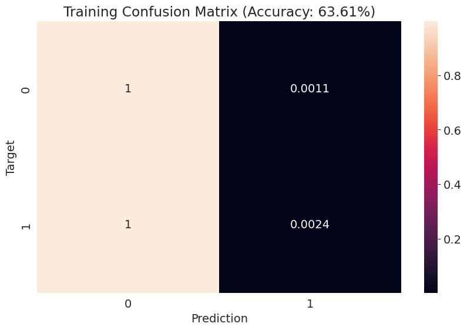

```python
train_preds = predict_and_plot(X_train, train_targets, 'Training')
```

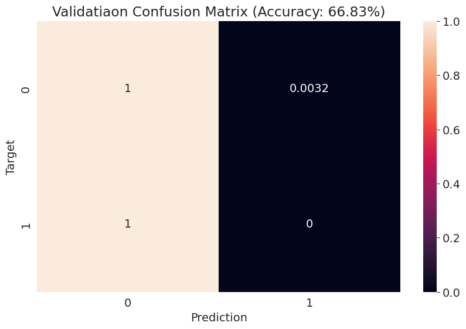

```python
val_preds = predict_and_plot(X_val, val_targets, 'Validatiaon')
```

```python
preds = model.predict(X_test)
```

## 7. Feature Engineering

### Scaling and One-Hot Encoding

**Exercise**: Try scaling numeric columns to the `(0,1)` range and encoding categorical columns using a one-hot encoder.

## 9. Tune Hyperparmeters

https://towardsdatascience.com/mastering-xgboost-2eb6bce6bc76

## 10. Document & Publish Your Work

- Add explanations using Markdown
- Clean up the code & create functions
- Publish notebook to Jovian
- Write a blog post and embed